# RaukR_twitter

Jonelly, Paloma, Ying

19/6/2019

For this project we did the following steps:

- Created a git repo: RaukR_twitter
- Imported data from twitter API using different criteria
- We builted functions for cleaning and graphing data
- Created a shinny app

# Data extraction

## Libraries we used

```r
library(rtweet)
library(tidyverse)
library(here)
library(glue)
library(rio)
```

## Criteria for filtering data

We used the `search_tweet` function from the `rtweet` package to bring all the tweets that used the `#bioinformatics`.

```r
data_week_bioinf <- search_tweets(
  "bioinformatics", n = 18000, include_rts = TRUE)
```

```r
data_week_bioinf %>%
  select(1:10) %>%
  glimpse
```

```
## Observations: 5,468
## Variables: 10
## $ user_id              <chr> "52926483", "172019745", "749287970742472...
## $ status_id            <chr> "1141310769348390912", "11413101782156410...
## $ created_at           <dttm> 2019-06-19 11:44:26, 2019-06-19 11:42:05...
## $ screen_name          <chr> "mmaug", "AggarwalAyush_", "DNAed_tech", ...
## $ text                 <chr> "Hi! I'm looking for a job! I have experi...
## $ source               <chr> "Twitter for Android", "Twitter for Andro...
## $ display_text_width   <dbl> 140, 140, 140, 140, 137, 140, 139, 140, 1...
## $ reply_to_status_id   <chr> NA, NA, NA, NA, NA, NA, NA, NA, NA, NA, N...
## $ reply_to_user_id     <chr> NA, NA, NA, NA, NA, NA, NA, NA, NA, NA, N...
## $ reply_to_screen_name <chr> NA, NA, NA, NA, NA, NA, NA, NA, NA, NA, N...
```

Since this function only brings data from the last 7 days, we asked for a twitter API token, in order to pull data from previous years.

We selected the top 20 usernames and used the function `get_timelines`, were we included a vector with 20 top users of last week

```r
top_users <- function(data, number) {
  top_users <- data %>%
    count(screen_name) %>%
    arrange(desc(n)) %>%
    top_n(number) %>%
    pull(screen_name)
  return(top_users)
}

users_top <- top_users(data_week_bioinf, 20)

timeline <- get_timelines(users_top,
                                n = 20000,
                                language = 'en',
                                since = '2018-01-01',
                                until = '2019-06-15',
                                token = token)
```

```r
timeline %>%
  select(1:10) %>%
  glimpse()
```

```
## Observations: 53,860
## Variables: 10
## $ user_id              <chr> "749287970742472708", "749287970742472708...
## $ status_id            <chr> "1141310185568428033", "11413101536246046...
## $ created_at           <dttm> 2019-06-19 11:42:07, 2019-06-19 11:41:59...
## $ screen_name          <chr> "DNAed_tech", "DNAed_tech", "DNAed_tech",...
## $ text                 <chr> "Have you seen our family history trainin...
## $ source               <chr> "Edtech genomics", "Edtech genomics", "Ed...
## $ display_text_width   <dbl> 140, 140, 140, 140, 140, 140, 140, 140, 1...
## $ reply_to_status_id   <chr> NA, NA, NA, NA, NA, NA, NA, NA, NA, NA, N...
## $ reply_to_user_id     <chr> NA, NA, NA, NA, NA, NA, NA, NA, NA, NA, N...
## $ reply_to_screen_name <chr> NA, NA, NA, NA, NA, NA, NA, NA, NA, NA, N...
```

# Graphs

## Trends over time of number of tweets

For all tweeter users, last week:

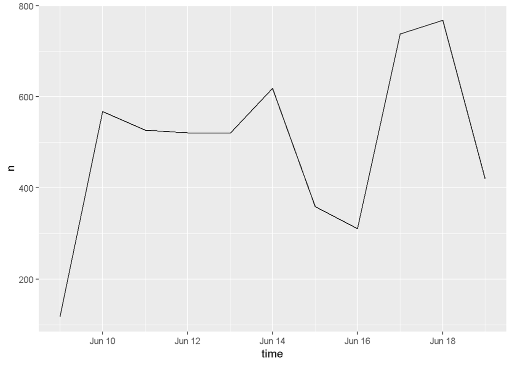

```r
ts_plot(data_week_bioinf, "days")
```

For the top 20 users, through all the years

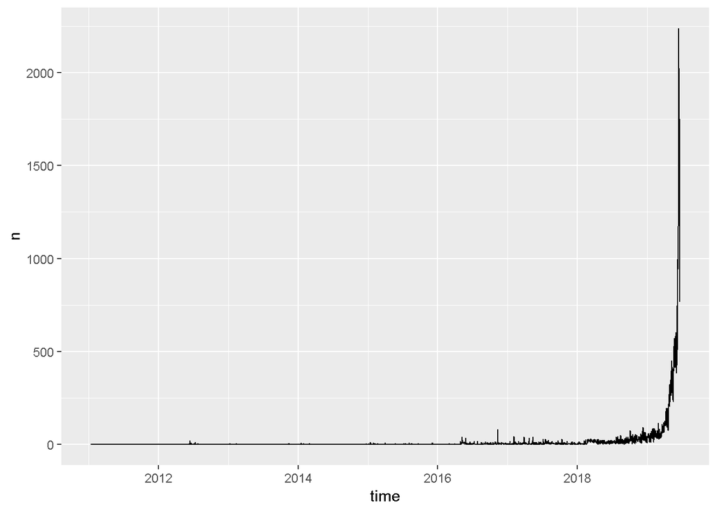

```r
ts_plot(timeline)
```

## Frequency plots

We wanted a frequency of tweets, by different variables, so we created a function

```r
bar_chart <- function(data, var1 = var1){
  var1 <- enquo(var1)
  label <- quo_name(var1)

  data %>%
    count(!! var1, sort = TRUE) %>%
    slice(1:20) %>%
    ggplot(aes(x = reorder(!! var1, -n), y = n, fill = !! var1)) +
    geom_bar(stat = "identity") +
    coord_flip() +
    labs(title = glue("Top twitter {label} in #bioinformatics"),
         x = glue("{label}")) +
    theme(plot.title = element_text(size = rel(2))) +
    theme_minimal() +
    theme(legend.position="none") +
    scale_fill_manual(
      values = colorRampPalette(
        RColorBrewer::brewer.pal(n = 25, name = "Spectral"))(25),
      guide = guide_legend(reverse = TRUE))

}
```

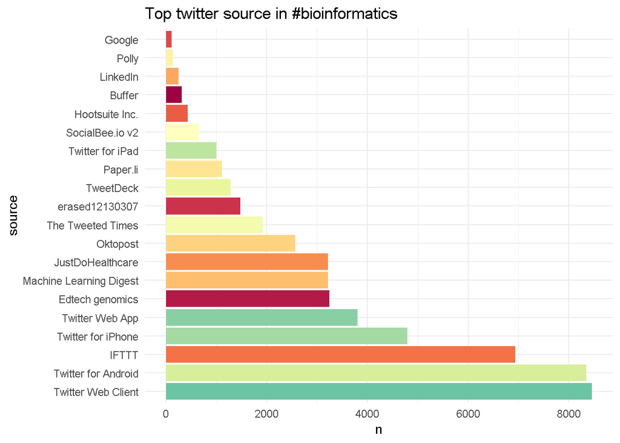

```r
bar_chart(timeline, var1 = source)
```

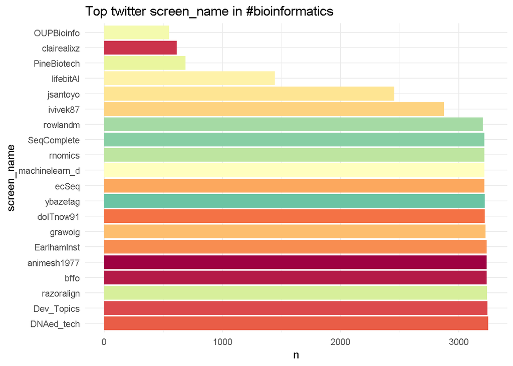

```r
bar_chart(timeline, var1 = screen_name)
```

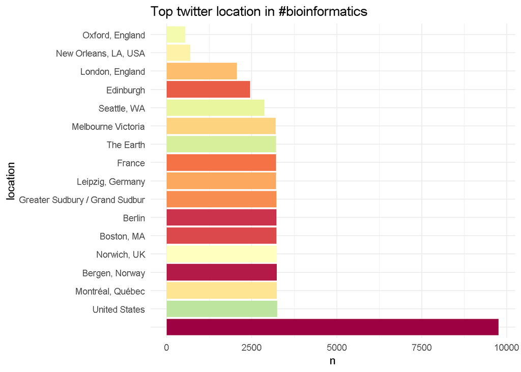

```r
bar_chart(timeline, var1 = location)
```

## Plot in maps

First it required some data cleaning

```r
## renaming and grouping cities into countries
loc_count <- timeline %>% count(location)

loc_count <- loc_count %>%
  mutate(Country = case_when(
    location %in% c("Melbourne Victoria ") ~ "Australia",
    location %in% c("Berlin","Leipzig, Germany") ~ "Germany",
    location %in% c("Greater Sudbury/Grand Sudbur","Montréal, Québec") ~ "Canada",
    location %in% c("France") ~ "France",
    location %in% c("Bergen,Norway") ~ "Norway",
    location %in% c("Edinburgh","London, England","Norwich, UK","Oxford, England") ~ "United Kingdom",
    location %in% c("Boston, MA","Seattle, WA","New Orleans, LA, USA", "United States") ~ "United States of America",
    location %in% c("The Earth") ~ "Earth",
    TRUE ~ "OTHER",
    ))

## getting total for plotting
total_by_country <- loc_count %>%
  group_by(Country) %>%
  summarize(Total=sum(n))

## making a sf
world <- ne_countries(scale = "medium", returnclass = "sf")
class(world)
```

```
## [1] "sf"         "data.frame"
```

```r
#total_by_country_merged
world_merged <- total_by_country %>%
  left_join(world, by = c("Country" = "sovereignt"))
```

### America

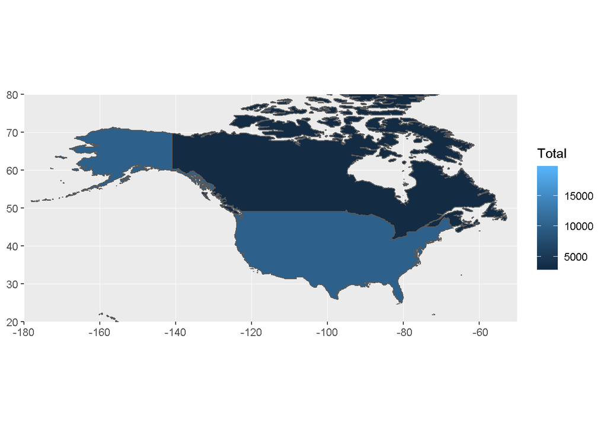

```r
ggplot(data = world_merged) +
  geom_sf(aes(fill = Total)) +
  coord_sf(xlim = c(-180.00,-50.00), ylim = c(20.00,80.00), expand = FALSE)
```

### Europe

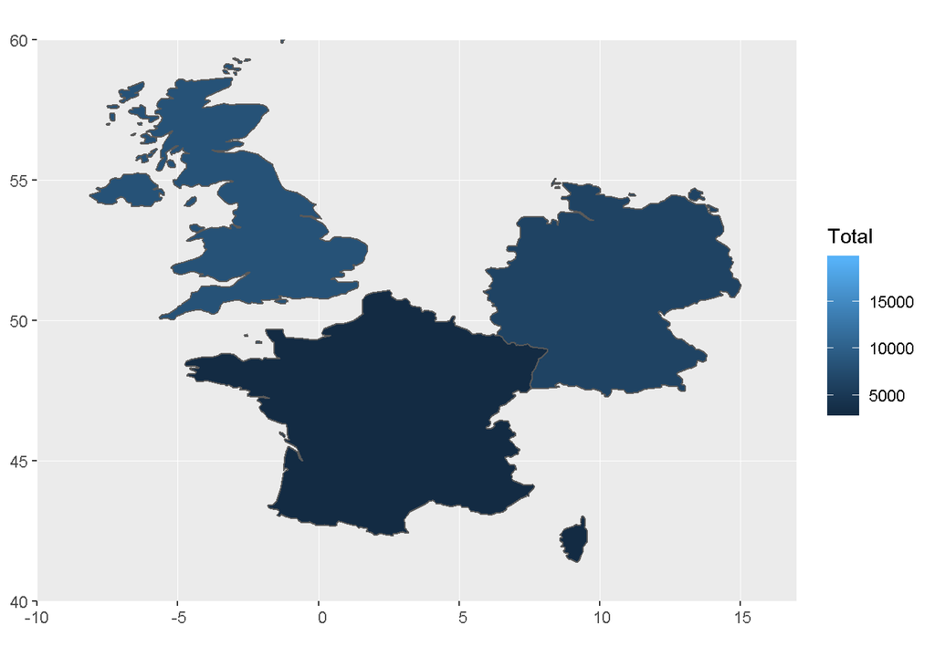

```r
ggplot(data = world_merged) +
  geom_sf(aes(fill = Total)) +
  coord_sf(xlim = c(-10.00,17.00), ylim = c(40.00,60.00), expand = FALSE)
```

## WordClouds

To make this possible we first had to clean the data that belogs to the `text` variable, this represents the content of the tweet.

We created a function that:

- Cleans spaces and symbols
- Creates a vector with words
- Filters words that are not stopwords or numbers
- Sorts the frequency in descendant
- Brings the rows defined in `rank`

```r
twitter_words <- function(data, rank) {

text <- timeline %>%
  mutate(text2 = gsub("^RT:?\\s{0,}|#|@\\S+|https?[[:graph:]]+", "", text),
         text2 = tolower(text2),
         text2 = gsub("^\\s{1,}|\\s{1,}$", "", text2),
         text2 = gsub("\\s{2,}", " ", text2)) %>%
  pull(text2)

words <- get_tokens(text, pattern = "\\W")
stopwords <- rcorpora::corpora("words/stopwords/en")$stopWords
numbers <- c(1:2019)
words <- as_tibble(words)

words_count <- words %>%
  filter(!value %in% stopwords) %>%
  filter(!value %in% numbers) %>%
  count(value, sort = TRUE) %>%
  slice(1:rank)

return(words_count)
}
```

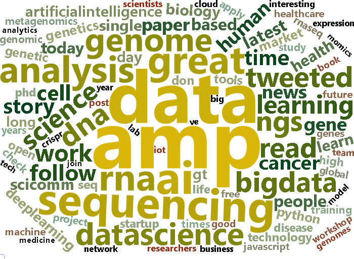

```r
week_top100 <- twitter_words(data_week_bioinf, rank = 100)
weekly <- wordcloud2(data = week_top100, size = 1,
           color = colorlist)

saveWidget(weekly,"1.html",selfcontained = F)
webshot::webshot("1.html","1.png",vwidth = 700, vheight = 500, delay =10)
```

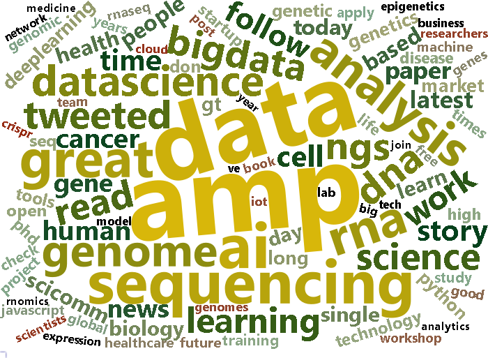

```r
timeline_top100 <- twitter_words(timeline, rank = 100)
timeline <- wordcloud2(data = week_top100, size = 1,
           color = colorlist)
saveWidget(timeline,"2.html",selfcontained = F)
webshot::webshot("2.html","2.png",vwidth = 700, vheight = 500, delay =10)
```